# Корреляция и регрессия

Притчин Иван

14 мая 2018 г

```r
library(magrittr)
```

Взглянув на диаграмму рассмеивания мы можем составить первое впечатление о том, насколько сильно и в каком направлении связаны две количественные переменные, однако, хотелось бы иметь что-то более конкретное. Не каждый раз смотреть на график а высчитать некоторый коэффициент.

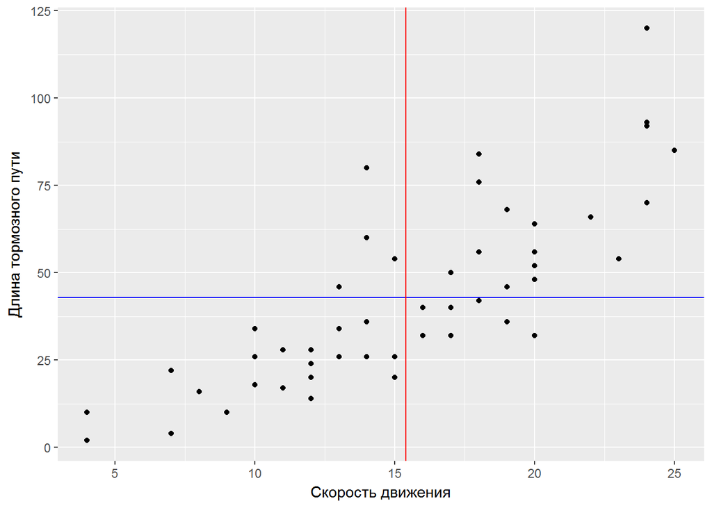

```r
library(ggplot2)
data <- cars
ggplot(cars, aes(speed, dist)) +
  geom_point() +
  geom_hline(yintercept = mean(cars$dist), color = "blue") +
  geom_vline(xintercept = mean(cars$speed), color = "red") +
  scale_x_continuous(name = "Скорость движения") +
  scale_y_continuous(name = "Длина тормозного пути")
```

```r
cor.test(data$speed, data$dist)
```

```
##
##  Pearson's product-moment correlation
##
## data:  data$speed and data$dist
## t = 9.464, df = 48, p-value = 1.49e-12
## alternative hypothesis: true correlation is not equal to 0
## 95 percent confidence interval:
##  0.6816422 0.8862036
## sample estimates:
##       cor
## 0.8068949
```

Для каждой точки мы можем вычитать произведение отклонений от среднего:
$$p = (x_i-\overline{X})*(y_i-\overline{Y})$$
Несколько прийти к выводу, что значние $p$ будет положительным в левом нижнем квадрате и в верхнем правом. В оставшихся областях значение будет отрицательным. Сумма произведений отвлонений, деленная на $N-1$ называется ковариацией.
$$cov = \frac{\sum_{1}^n(x_i-\overline{X})*(y_i-\overline{Y})}{N-1}$$
Важно отметить, что значение ковариации может принимать любое значение. Величина определяется значением дисперсии по осям. Для приведения к некоторому стандартному виду, используется коэффициент корреляции:
$$r_{xy}=\frac{cov}{\sigma_x\sigma_y}$$
Такое преобразование гарантирует принадлежность результата промежутку $[-1; 1]$.

Квадрат коэффициента корреляции называется коэффициентом детерминации, который показывает в каком степени дисперсия одной переменной обусловлена влиянием другой переменной.

##### Условия применения коэффициента корреляции

Условиями применения корреляции является линейность и монотонность данных.

Примеры нелинейной взаимосвязи могут давать корреляцию близкую к нулю. В целом, нечувствителен к нелинейным взаимосвязям. Коэффициент будет равен близок к нулю, но взаимосвязь, очевидно, есть.

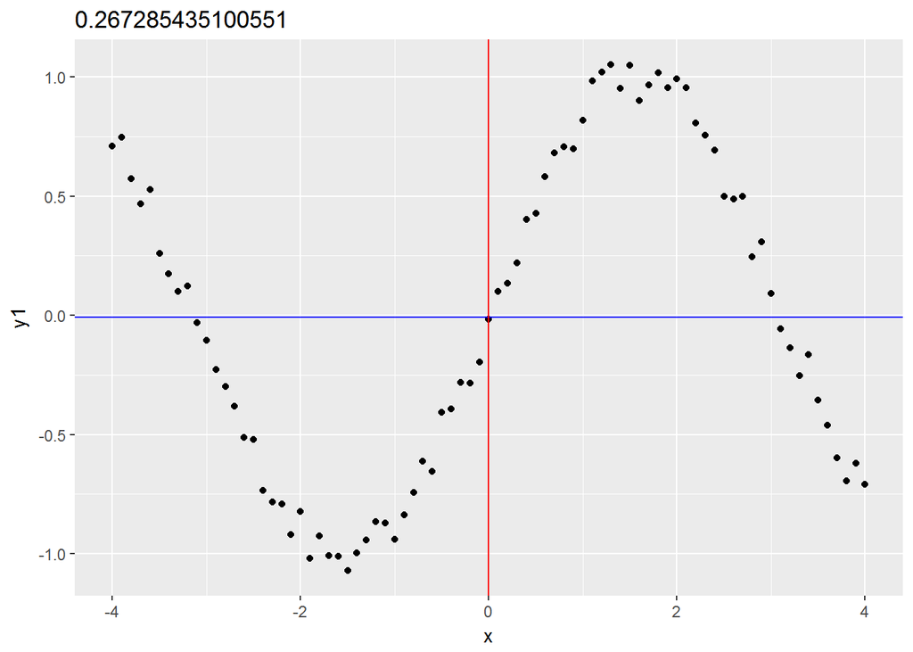

```r
x = seq(-4, 4, by = 0.1)
make_noise <- function(y, half_range) {
  y + runif(length(y), -half_range, half_range)
}
y1 <- sin(x) %>% make_noise(0.1)
qplot(x, y1) + labs(title=cor(x, y1)) +
  geom_hline(yintercept = mean(y1), color = "blue") +
  geom_vline(xintercept = mean(x), color = "red")
```

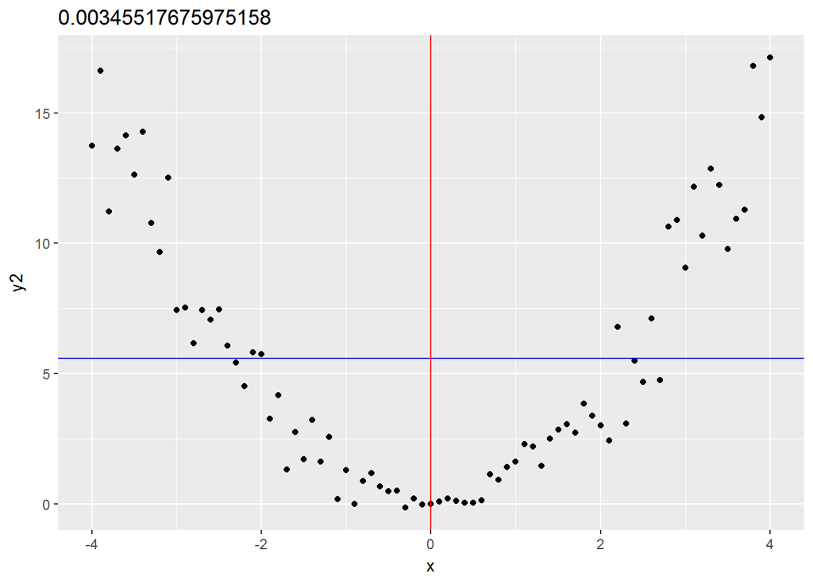

```r
y2 <- x*x %>% make_noise(1)
qplot(x, y2) + labs(title=cor(x, y2)) + geom_hline(yintercept = mean(y2), color = "blue") +
  geom_vline(xintercept = mean(x), color = "red")
```

Могут попадаться случаи, когда зависимость лучше описывается двумя прямыми, что приводит к тому, что коэффициент корреляции может давать нехорошие результаты.

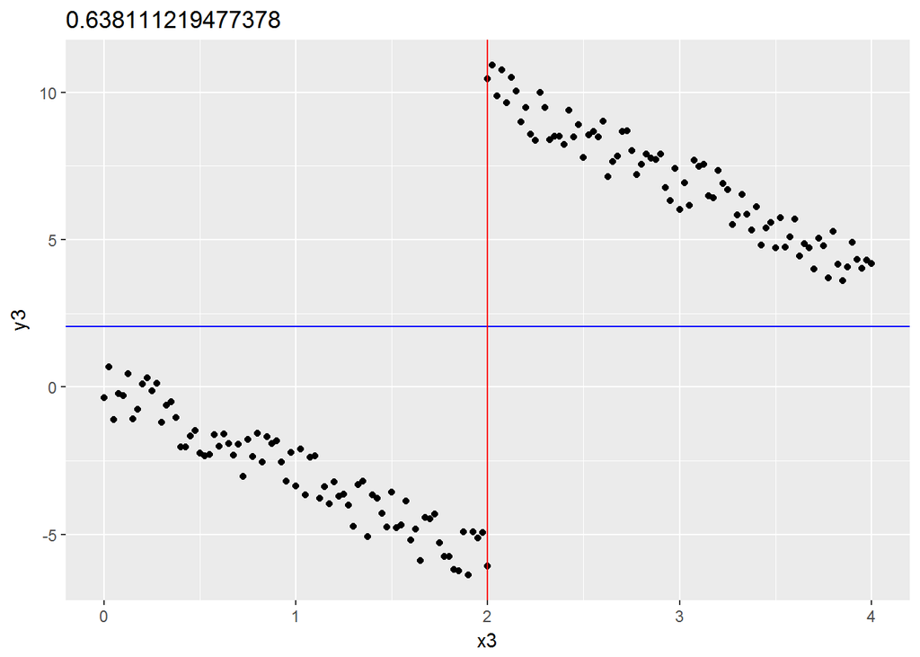

```r
x3 <- c(seq(0, 2, 0.025), seq(2, 4, 0.025))
y3 <- c(-3*x3[1:81], -3*x3[82:162]+16) %>% make_noise(1)
qplot(x3, y3) + labs(title=cor(x3, y3)) +
  geom_hline(yintercept = mean(y3), color = "blue") +
  geom_vline(xintercept = mean(x3), color = "red")
```

Важно отметить, что коэффициент очень сильно подвержен выбросам.

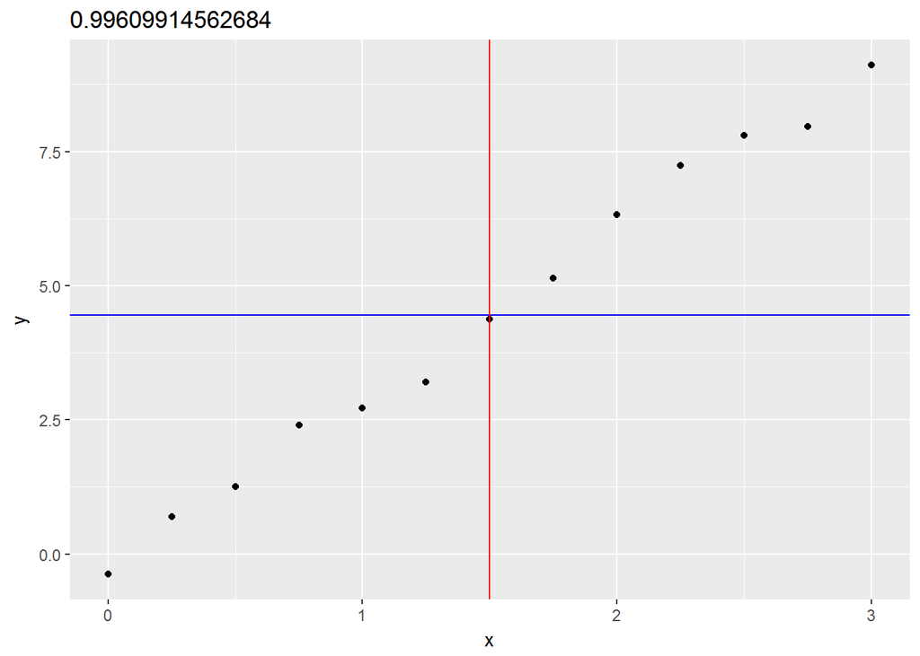

```r
x <- seq(0, 3, 0.25)
y <- 3*x %>% make_noise(0.2)
qplot(x, y) + labs(title=cor(x, y)) +
  geom_hline(yintercept = mean(y), color = "blue") +
  geom_vline(xintercept = mean(x), color = "red")
```

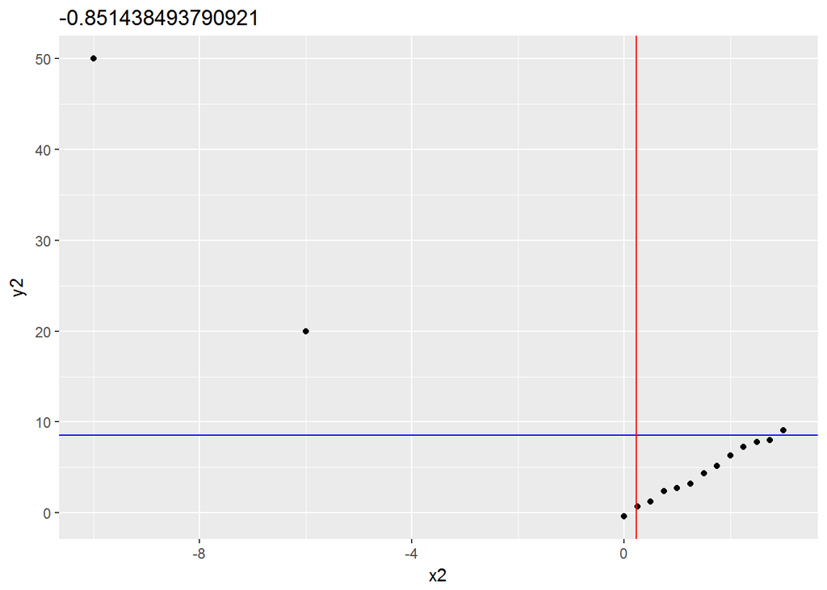

```r
x2 <- c(x, -6, -10)
y2 <- c(y, 20, 50)
qplot(x2, y2) + labs(title=cor(x2, y2)) +
  geom_hline(yintercept = mean(y2), color = "blue") +
  geom_vline(xintercept = mean(x2), color = "red")
```

Вывод: перед применением коэффициента корреляции важно построить график. Также, было бы неплохо, если переменые x и y были распределены нормально (из-за идеи, которая лежит в основе вычисления).

##### Корреляция Спирмана

Если есть нарушения условий, можно использовать некоторые непараметрические аналоги. Например, корреляция Спирмана позволяет нам менее чувствительно ощущать последствия выбросов. Смоделируем работу по нахождению корреляции на языке R

```r
# 1. Перевети переменные x и y в разряд ранговых
rank_x2 <- rank(x2)
rank_y2 <- rank(y2)
N <- length(x2)
d2 <- abs(rank_x2 - rank_y2)^2
rs <- 1 - 6*sum(d2)/(N*(N^2 - 1))
data.frame(x2, y2, rank_x2, rank_y2, d2)
```

```
##        x2         y2 rank_x2 rank_y2  d2
## 1    0.00 -0.3724730       3       1   4
## 2    0.25  0.6998114       4       2   4
## 3    0.50  1.2609019       5       3   4
## 4    0.75  2.3989544       6       4   4
## 5    1.00  2.7143611       7       5   4
## 6    1.25  3.2101902       8       6   4
## 7    1.50  4.3769559       9       7   4
## 8    1.75  5.1421693      10       8   4
## 9    2.00  6.3249405      11       9   4
## 10   2.25  7.2461971      12      10   4
## 11   2.50  7.8048988      13      11   4
## 12   2.75  7.9724500      14      12   4
## 13   3.00  9.1141700      15      13   4
## 14  -6.00 20.0000000       2      14 144
## 15 -10.00 50.0000000       1      15 196
```

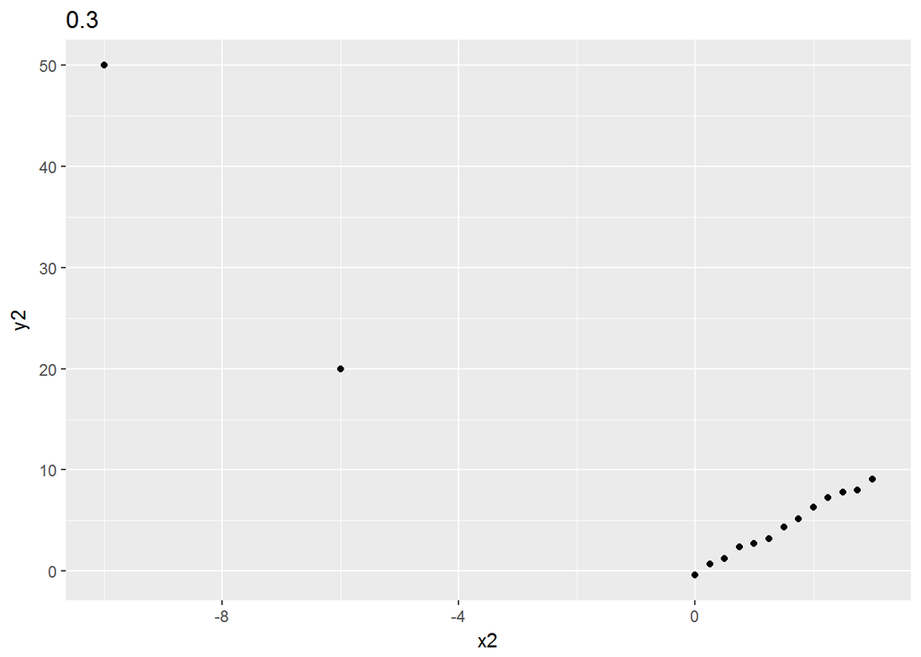

```r
qplot(x2, y2) + labs(title=cor(x2, y2, method = "spearman"))
```

#### Корреляция и причинно-следственная связь

Стремящаяся к единице по модулю корреляция ничего не говорит нам и причинно-следственной связи.

## TODO

Тут надо обязательно рассказать про ложную корреляцию, пиратов и глобальное потепление http://www.tylervigen.com/spurious-correlations https://www.popmech.ru/science/237232-lozhnye-korrely.. https://habr.com/post/236503/

### Регрессия с одной переменной

Линия регрессии показывает нам, как одна переменная объясняет предсказать нам другую переменную. В общем виде
$$y=\beta_0+\beta_1*x$$
где $\beta_0$ - intercept (определяет точку пересения с осью y), $\beta_1$ - slope (определяет угол наклона). Задача - подобрать эти два параметра, чтобы линия максимально точно отражала взаимосвязь двух количественный переменных Метод наименьших квадратов - метод нахождения оптимальных параметров линейной регрессии, таких, что сумма квадратов ошибок ($e_i = y_i-\hat{y_1}$) была минимальна. Оцениваются квадраты по причине того, что остатки поглащали друг друга.
$$\beta_1=\frac{sd_y}{sd_x}*r_{xy}$$
$$\beta_0=\overline{Y}-\beta_1*\overline{X}$$
Вопрос о статистической значимости получнной линии регрессии. Если бы не было взаимосвязи между переменными, мы бы получили, что значение $\beta_1 = 0$, $\beta_2=\overline{Y}$. Альтернативная гипотеза: $\beta_0 \neq 0$. Решение идёт через t-критерий, который говорит следующее: если бы мы многократно повторяли наш эксперимент в ситуации, что у нас никакой взаимосвязи нет, то выборочные значения коэффициентов $\beta_1$ распределились бы нормальным образом вокруг соответствующего значения генеральной совокупности и отклонялись бы то в правую, то в левую сторону от нуля. В таких случаях хорошо использовать t-распределение. Расчитаем t-критерий. Который заключается с том, насколько выборочное среднее отклонилось от ожидаемого значения в генеральной совокупности, которым является 0, деленное на стандартную ошибку распределения этого коэффициента
$$t=\frac{\beta_1}{se}$$
$df = N-2$ Коэффициент детерминации - доля дисперсии одной переменной, обуславливаемая её взаимосвязью с другой переменной.
$$R^2=1-\frac{SS_{res}}{SS_{total}}$$
$$SS_{res}=\sum_{i=1}^n{e^2}$$
$$SS_{total}=\sum_{i=1}^n{(y-\overline{y})}$$
##### Условия применения линейной регрессии с одним предиктором Линейная взаимосвязь
Нормальное распределение остатков Гомоскедастичность - постоянная изменчивость остатоков на всех уровнях независимой переменной.

##### Применение регрессионного анализа и интерпритация остатков

```r
data <- read.csv(file = "datasets/states.csv")
head(data)
```

```
##        state metro_res white hs_grad poverty female_house
## 1    Alabama      55.4  71.3    79.9    14.6         14.2
## 2     Alaska      65.6  70.8    90.6     8.3         10.8
## 3    Arizona      88.2  87.7    83.8    13.3         11.1
## 4   Arkansas      52.5  81.0    80.9    18.0         12.1
## 5 California      94.4  77.5    81.1    12.8         12.6
## 6   Colorado      84.5  90.2    88.7     9.4          9.6
```

```r
str(data)
```

```
## 'data.frame':    51 obs. of  6 variables:
##  $ state       : Factor w/ 51 levels "Alabama","Alaska",..: 1 2 3 4 5 6 7 8 9 10 ...
##  $ metro_res   : num  55.4 65.6 88.2 52.5 94.4 84.5 87.7 80.1 100 89.3 ...
##  $ white       : num  71.3 70.8 87.7 81 77.5 90.2 85.4 76.3 36.2 80.6 ...
##  $ hs_grad     : num  79.9 90.6 83.8 80.9 81.1 88.7 87.5 88.7 86 84.7 ...
##  $ poverty     : num  14.6 8.3 13.3 18 12.8 9.4 7.8 8.1 16.8 12.1 ...
##  $ female_house: num  14.2 10.8 11.1 12.1 12.6 9.6 12.1 13.1 18.9 12 ...
```

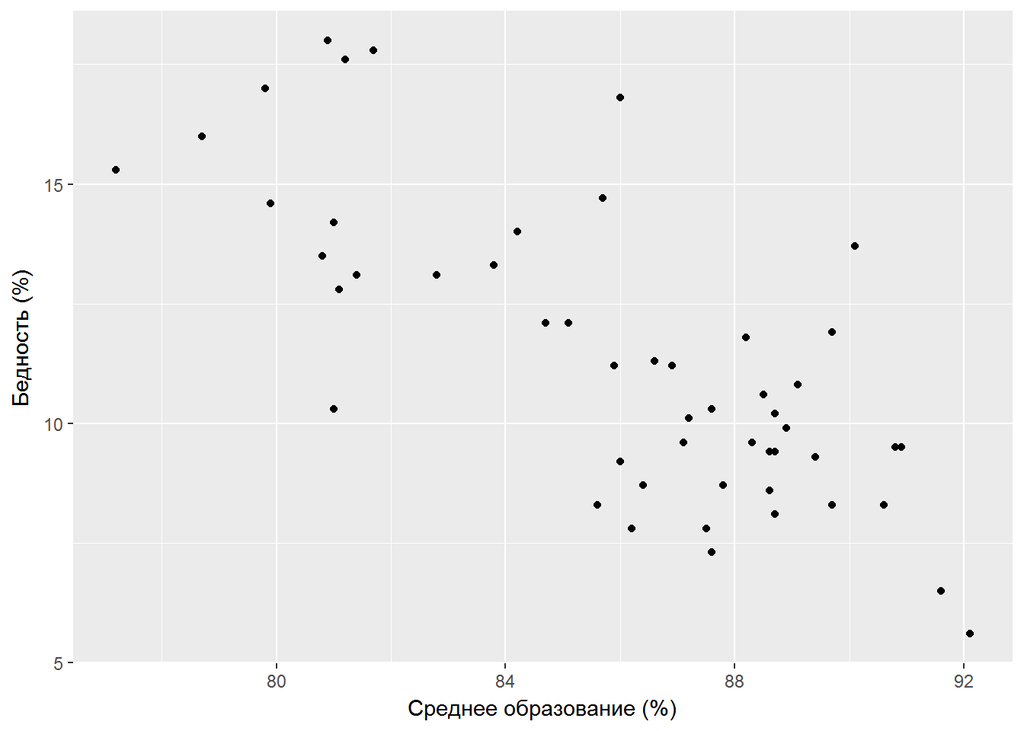

```r
qplot(x = hs_grad, y = poverty, data = data) +
  scale_x_continuous(name = "Среднее образование (%)") +
  scale_y_continuous(name = "Бедность (%)")
```

```r
fit <- lm(data = data, formula = poverty~hs_grad)
summary(fit)
```

```
##
## Call:
## lm(formula = poverty ~ hs_grad, data = data)
##
## Residuals:
##     Min      1Q  Median      3Q     Max
## -4.1624 -1.2593 -0.2184  0.9611  5.4437
##
## Coefficients:
##             Estimate Std. Error t value Pr(>|t|)
## (Intercept) 64.78097    6.80260   9.523 9.94e-13 ***
## hs_grad     -0.62122    0.07902  -7.862 3.11e-10 ***
## ---
## Signif. codes:  0 '***' 0.001 '**' 0.01 '*' 0.05 '.' 0.1 ' ' 1
##
## Residual standard error: 2.082 on 49 degrees of freedom
## Multiple R-squared:  0.5578, Adjusted R-squared:  0.5488
## F-statistic: 61.81 on 1 and 49 DF,  p-value: 3.109e-10
```

В строке с образованием, мы можем заметить, что p-значение меньше 0.05, что говорит о статистически значимой взаимосвязи между двумя переменными. У коэффициента детерминации есть свой p-уровень значимости и значение F-критерия. P-значение для коэффициента детерминации - это некоторая оценка к нашей модели в целом.

#### Задача предсказания в регрессионном анализе

#### Множественная регрессия

Включает несколько предикторов. Работает аналогично.

```r
fit <- lm(data, formula = poverty ~ metro_res + white + hs_grad + female_house)
summary(fit)
```

```
##
## Call:
## lm(formula = poverty ~ metro_res + white + hs_grad + female_house,
##     data = data)
##
## Residuals:
##    Min     1Q Median     3Q    Max
## -3.289 -1.506 -0.323  1.235  4.449
##
## Coefficients:
##              Estimate Std. Error t value Pr(>|t|)
## (Intercept)  66.47653   12.58990   5.280 3.41e-06 ***
## metro_res    -0.05632    0.01955  -2.881    0.006 **
## white        -0.04814    0.03306  -1.456    0.152
## hs_grad      -0.55471    0.10491  -5.288 3.33e-06 ***
## female_house  0.05054    0.24330   0.208    0.836
## ---
## Signif. codes:  0 '***' 0.001 '**' 0.01 '*' 0.05 '.' 0.1 ' ' 1
##
## Residual standard error: 1.934 on 46 degrees of freedom
## Multiple R-squared:  0.6416, Adjusted R-squared:  0.6104
## F-statistic: 20.58 on 4 and 46 DF,  p-value: 8.884e-10
```

Однако, стоит отметить, что включение в модель всех параметров далеко не является лучшим решением. Попробуем улучшить модель. Рассмотрим, как переменные коррелируют между собой.

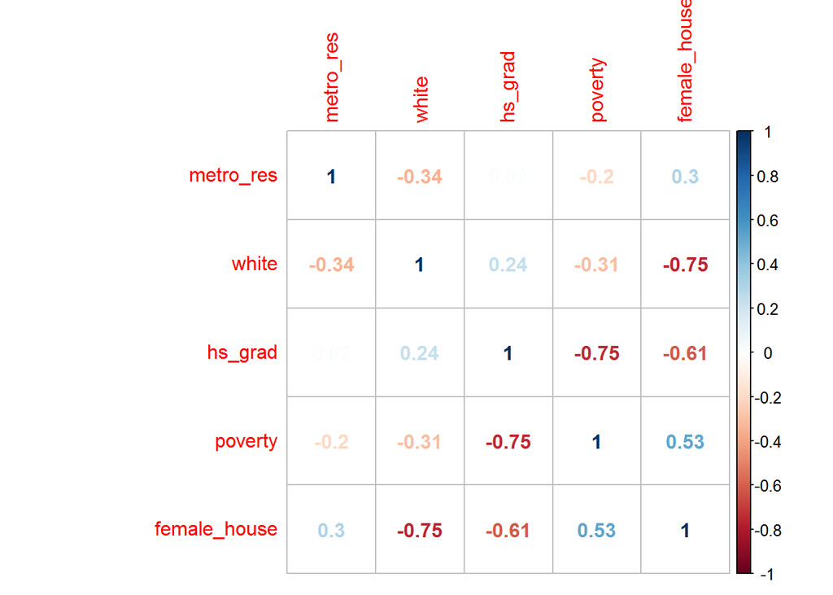

```r
corrplot::corrplot(cor(as.data.frame(data[-1])), method = "number")
```

```r
fit <- lm(data, formula = poverty ~ metro_res + white + hs_grad)
summary(fit)
```

```
##
## Call:
## lm(formula = poverty ~ metro_res + white + hs_grad, data = data)
##
## Residuals:
##     Min      1Q  Median      3Q     Max
## -3.2346 -1.4785 -0.3699  1.2153  4.5579
##
## Coefficients:
##             Estimate Std. Error t value Pr(>|t|)
## (Intercept) 68.72202    6.38893  10.756 2.89e-14 ***
## metro_res   -0.05553    0.01898  -2.926  0.00528 **
## white       -0.05333    0.02148  -2.483  0.01665 *
## hs_grad     -0.56972    0.07527  -7.569 1.13e-09 ***
## ---
## Signif. codes:  0 '***' 0.001 '**' 0.01 '*' 0.05 '.' 0.1 ' ' 1
##
## Residual standard error: 1.915 on 47 degrees of freedom
## Multiple R-squared:  0.6412, Adjusted R-squared:  0.6183
## F-statistic:    28 on 3 and 47 DF,  p-value: 1.553e-10
```

Как видим, исправленный R-квадрат стал чуть выше. Однако, при попытке дальнейшего исключения параметров из модели - предсказательная способность не будет становиться лучше.

Вопрос о нелинейности связи. Рассмотрим следующий случай

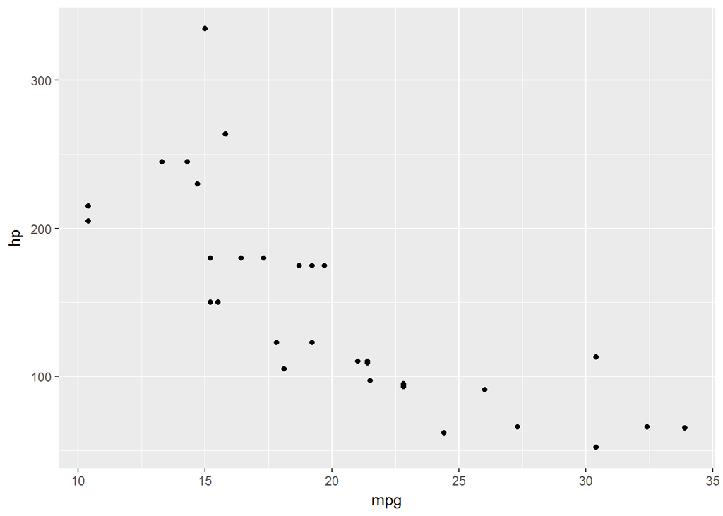

```r
library(ggplot2)
ggplot() +
  geom_point(data = mtcars, aes(mpg, hp))
```

Как мы видим, связь не является линейной. Можно выполнить ряд преобразований над данными, чтобы получить линейную взяимосвязь, с которой хорошо будет работать линейная регрессия. Решением может быть тренсформация Тьюки. Основная идея - трансформировать независимую переменную, чтобы ликвидировать нелинейность связи. Мы хотим подобрать такой показатель степени, в который можно возвести каждое из значений независимой переменной так, чтобы итоговая взаимосвязь стала более линейной. Если лучшим значением является значение в нулевой степени - применяем натуральный логарифм.

```r
manipulate(
  ggplot() +
    geom_point(data = mtcars, aes(mpg, hp^st)),
  st = slider(0.5, 2, initial = 1)
)
```

##### Логистическая регрессия

Позволяет нам исследовать взаимосвязи между зависимой переменной, которая имеет всего лишь две градации и различными предикторами. Позволяет решать целый спектр задач.